# Checking Reports: Janaagraha vs Reap Benefit - Bangalore

We have totally 14780 reports on the Solve Ninja App.

Of these, 8002 are actually from Bangalore. We will analyse these only currently.

We have received from JG a set of 3392 issues.

There are 2046 issues that are present in both databases.

5956 issues are not present in the JG database. This was becauseof data not generated by us but pulled by error.

# Cross Tabulation of results

## Rows are Reap Benefit’s status, Columns are JG status

|  | Forworded to Agency | On-the-Job | Open | Rejected | Resolved | Not present in JG |
| --- | --- | --- | --- | --- | --- | --- |
| On-the-Job | 0 | 13 | 0 | 0 | 138 | 1498 |
| Open | 0 | 7 | 941 | 9 | 735 | 1128 |
| Re-opened | 0 | 0 | 0 | 0 | 0 | 229 |
| Rejected | 0 | 0 | 0 | 47 | 0 | 584 |
| Resolved | 1 | 0 | 1 | 0 | 154 | 2517 |

# Investigating failure rates

## Failures are issues that are not present in the JG database - but present in ours

## Overall Failure rate across months

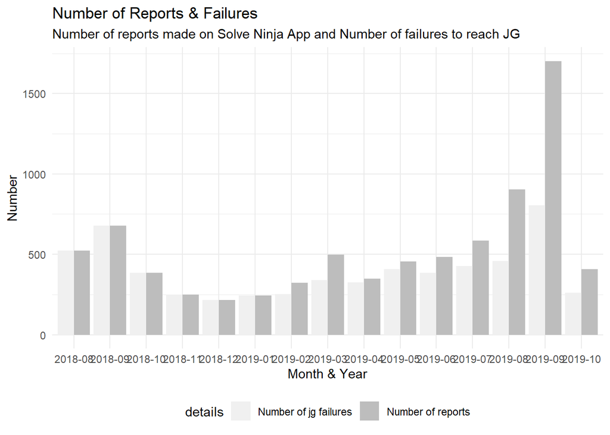

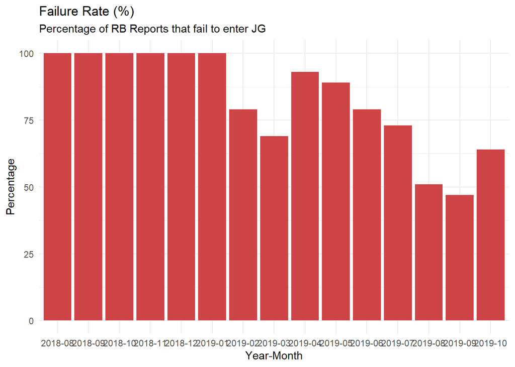

### We have quite a significant failure rate - reguarly >50%.

| create_month_year | details | values |
| --- | --- | --- |
| 2018-08 | Failure rate | 100 |
| 2018-09 | Failure rate | 100 |
| 2018-10 | Failure rate | 100 |
| 2018-11 | Failure rate | 100 |
| 2018-12 | Failure rate | 100 |
| 2019-01 | Failure rate | 100 |
| 2019-02 | Failure rate | 79 |
| 2019-03 | Failure rate | 69 |
| 2019-04 | Failure rate | 93 |
| 2019-05 | Failure rate | 89 |
| 2019-06 | Failure rate | 79 |
| 2019-07 | Failure rate | 73 |
| 2019-08 | Failure rate | 51 |
| 2019-09 | Failure rate | 47 |
| 2019-10 | Failure rate | 64 |

### The primary reason seems to be that we pulled data that actually is not generated by Solve Ninja app. So then we analyse data from known users

## Failure rate among known users

| create_month_year | Number of reports | Number of jg failures | Failure rate |
| --- | --- | --- | --- |
| 2019-02 | 9 | 2 | 22 |
| 2019-03 | 146 | 14 | 10 |
| 2019-04 | 30 | 13 | 43 |
| 2019-05 | 70 | 44 | 63 |
| 2019-06 | 112 | 14 | 12 |
| 2019-07 | 194 | 53 | 27 |
| 2019-08 | 450 | 46 | 10 |
| 2019-09 | 1275 | 411 | 32 |
| 2019-10 | 162 | 14 | 9 |

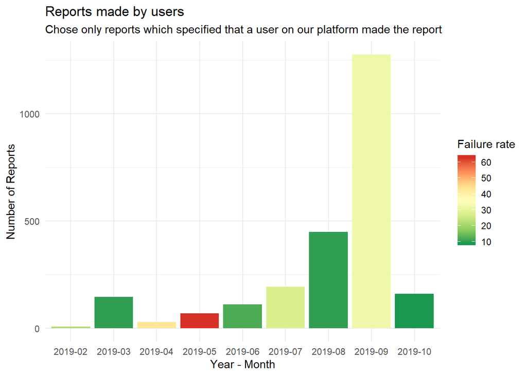

### We ran campaigns on blackspots and single use plastics - these should also not be in the analaysis

# Campaigns run last month seem to push failure rate up - so removed and ran again

| create_month_year | Number of reports | Number of jg failures | Failure rate |
| --- | --- | --- | --- |
| 2019-02 | 9 | 2 | 22 |
| 2019-03 | 146 | 14 | 10 |
| 2019-04 | 30 | 13 | 43 |
| 2019-05 | 70 | 44 | 63 |
| 2019-06 | 112 | 14 | 12 |
| 2019-07 | 194 | 53 | 27 |
| 2019-08 | 450 | 46 | 10 |
| 2019-09 | 943 | 79 | 8 |
| 2019-10 | 157 | 9 | 6 |

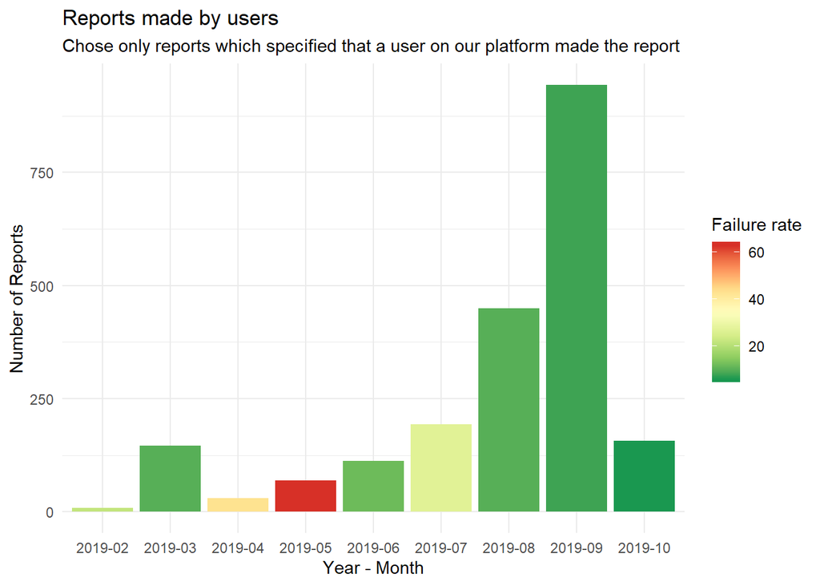

### Failure rate drops to less than 10%. Can we improve this?

## Unknown user analysis - ran this to see if there are any trends coming out

| create_month_year | Number of reports | Number of jg failures | Failure rate |
| --- | --- | --- | --- |
| 2018-08 | 522 | 522 | 100 |
| 2018-09 | 677 | 677 | 100 |
| 2018-10 | 384 | 384 | 100 |
| 2018-11 | 251 | 251 | 100 |
| 2018-12 | 215 | 215 | 100 |
| 2019-01 | 245 | 245 | 100 |
| 2019-02 | 314 | 252 | 80 |
| 2019-03 | 351 | 327 | 93 |
| 2019-04 | 319 | 313 | 98 |
| 2019-05 | 385 | 363 | 94 |
| 2019-06 | 373 | 370 | 99 |
| 2019-07 | 391 | 373 | 95 |
| 2019-08 | 454 | 413 | 91 |
| 2019-09 | 427 | 394 | 92 |
| 2019-10 | 246 | 246 | 100 |

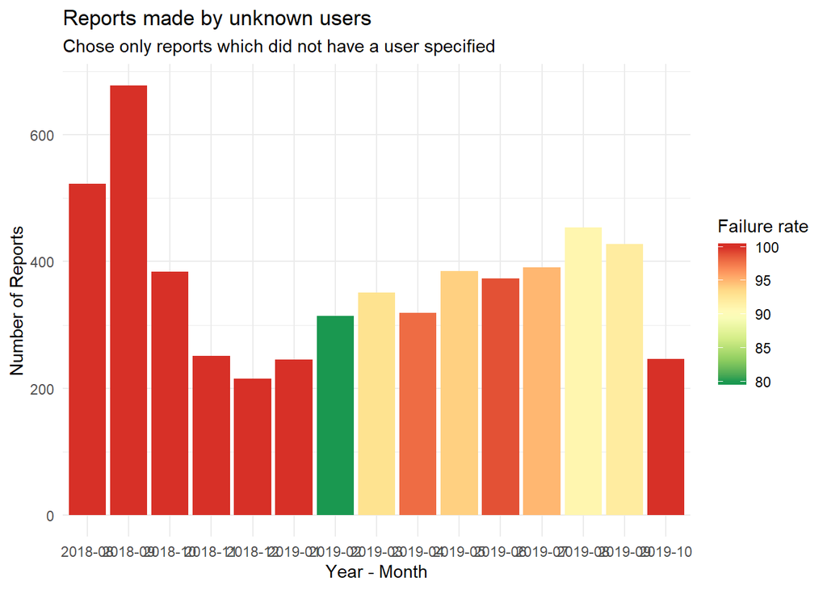

### High failure rate here - not much to infer. This is just be the data that isn’t generated by SNA - so it’s likely that we just don’t have access to the completion data

# Resolution Rate - among users whose issues are accepted in the Janaagraha System

| create_month_year | Number of reports | Number of Resolutions | Resolution rate |
| --- | --- | --- | --- |
| 2019-02 | 7 | 4 | 57 |
| 2019-03 | 132 | 85 | 64 |
| 2019-04 | 17 | 14 | 82 |
| 2019-05 | 26 | 23 | 88 |
| 2019-06 | 98 | 84 | 86 |
| 2019-07 | 141 | 115 | 82 |
| 2019-08 | 404 | 301 | 75 |
| 2019-09 | 864 | 285 | 33 |
| 2019-10 | 148 | 2 | 1 |

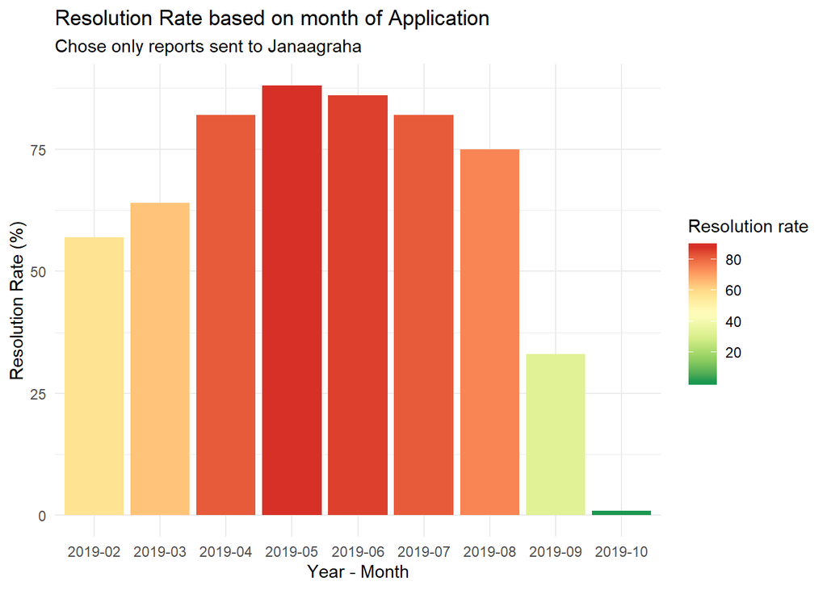

### Our 3 month reolution rate approaches is upwards of 80%. Approaches 90% after 6 months.

# Resolution Rate (%) - among users whose issues are accepted by Janaagraha - as per civic agency

| Year-Month | BBMP | BTP | BWSSB | KSPCB |
| --- | --- | --- | --- | --- |
| 2019-02 | 100 | NA | NA | 0 |
| 2019-03 | 100 | 0 | 10 | 0 |
| 2019-04 | 100 | NA | NA | 0 |
| 2019-05 | 100 | 0 | 0 | 0 |
| 2019-06 | 92 | 100 | 12 | NA |
| 2019-07 | 97 | 50 | 0 | 0 |
| 2019-08 | 99 | 12 | 0 | 0 |
| 2019-09 | 42 | 12 | 0 | 0 |
| 2019-10 | 1 | 17 | 0 | 0 |

### With BBMP our resolution rate climbs to 99%